# Effectiveness of working out

Pascal Spijkerman

11/01/2020

# The effectiveness of working out

This paper discusses the development of a machine learning algorithm that predicts the manner of performing various exercises by tracking these excercises via accelerometers.

The machine learning is build on th etraining set from the Human Activity Recognition. More information may be found here: http://web.archive.org/web/20161224072740/http:/groupware.les.inf.puc-rio.br/har

Velloso, E.; Bulling, A.; Gellersen, H.; Ugulino, W.; Fuks, H. “Qualitative Activity Recognition of Weight Lifting Exercises. Proceedings of 4th International Conference in Cooperation with SIGCHI (Augmented Human ’13)”. Stuttgart, Germany: ACM SIGCHI, 2013.

A short description of the datasets content from the authors’ website:

“Six young health participants were asked to perform one set of 10 repetitions of the Unilateral Dumbbell Biceps Curl in five different fashions: exactly according to the specification (Class A), throwing the elbows to the front (Class B), lifting the dumbbell only halfway (Class C), lowering the dumbbell only halfway (Class D) and throwing the hips to the front (Class E).

Class A corresponds to the specified execution of the exercise, while the other 4 classes correspond to common mistakes. Participants were supervised by an experienced weight lifter to make sure the execution complied to the manner they were supposed to simulate. The exercises were performed by six male participants aged between 20-28 years, with little weight lifting experience. We made sure that all participants could easily simulate the mistakes in a safe and controlled manner by using a relatively light dumbbell (1.25kg)."

## Importing data

We start by importing the training set and testing set.

```r
library(tidyverse)
library(moderndive)
library(skimr)
library(caret)
library(kernlab)
library(ISLR)
library(gridExtra)
library(Hmisc)
library(rattle)
library(randomForest)
library(gbm)
library(corrplot)
library(rpart)

TrainingData <- read.csv("./pml-training.csv")
TestingData <- read.csv("./pml-testing.csv")
```

## Exploratory Data Analysis and data cleansing

```r
glimpse(TrainingData)
```

[output not shown]

```r
# Remove identification variables (first 5 variables of the dataset)
training <- TrainingData[, -(1:5)]
testing  <- TestingData[, -(1:5)]

# Cleaning values with nearly zero variance
NZV <- nearZeroVar(training)
training <- training[, -NZV]
testing <- testing[, -NZV]

# Removing NA Values
na_variables <- sapply(training, function(x) mean(is.na(x))) > 0.95
training <- training[ ,na_variables == FALSE]
testing <- testing[ ,na_variables == FALSE]

# Splitting trainingdata into a trainingdata and validation data
inTrain <- createDataPartition(training$classe, p = 0.75, list = FALSE)

trainingset <- training[inTrain,]
testingset <- training[-inTrain,]
dim(trainingset); dim(testingset)
```

```
## [1] 14718    54
```

```
## [1] 4904   54
```

```r
trainingset <- as.data.frame(trainingset)
testingset <- as.data.frame(testingset)
```

## Correlation analysis

In this chapter, we will analyse the correlations of all variables. There are a few higly correlated values, which could be cleaned from the data. However, as my computer took to long for th emodel to be build after processing, we will stich with this matrix and do not apply further preprocessing to remove highly correlated values.

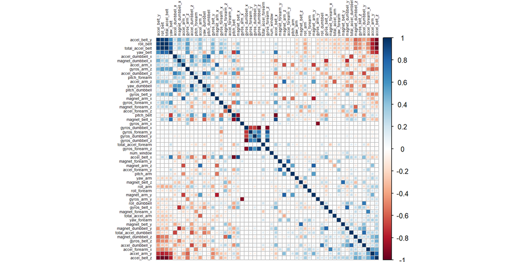

```r
cor_matrix <- cor(training[sapply(training, is.numeric)])
corrplot(corr = cor_matrix, order = "FPC", method = "square", tl.cex = 0.45, tl.col = "black", number.cex = 0.25)
```

## Model Building

In this section, we will create a model based on the trainingset.

```r
modelfit <- randomForest(classe~., data = trainingset)
```

We can also build a decision tree.

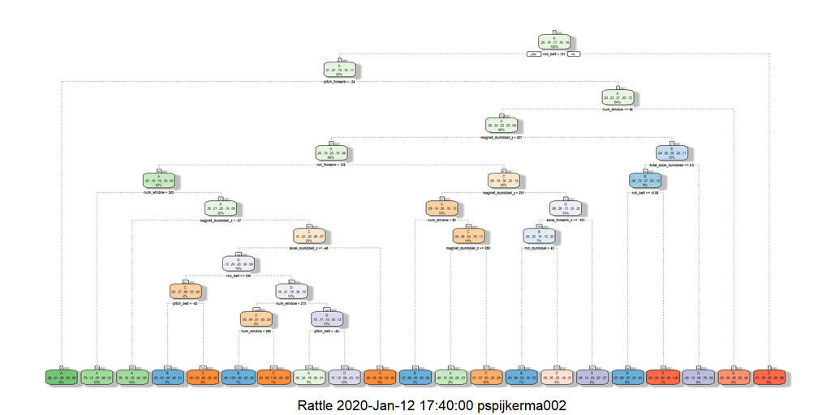

```r
tree <- rpart(classe ~., data = trainingset)
fancyRpartPlot(tree)
```

```r
predictions <- predict(modelfit, testing)
predictions
```

```
##  1  2  3  4  5  6  7  8  9 10 11 12 13 14 15 16 17 18 19 20
##  B  A  B  A  A  E  D  B  A  A  B  C  B  A  E  E  A  B  B  B
## Levels: A B C D E
```